# Using HIP on Setonix

## Access to Setonix

Firstly you need a username and password to access Setonix. Your **username** and **password** will be given to you prior to the beginning of this workshop. If you are using your regular Pawsey account then you can reset your password [here](https://support.pawsey.org.au/password-reset/).

Access to Setonix is via Secure SHell (SSH). On Linux, Mac OS, and Windows 10 and higher, an SSH client is available from the command line or terminal application. Otherwise you need to use a client program like [Putty](https://www.putty.org/) or [MobaXterm](https://mobaxterm.mobatek.net/download-home-edition.html).

### Access with SSH on the command line

On the command line use the command **ssh** to access Setonix.

```
ssh -Y <username>@setonix.pawsey.org.au
```

#### Passwordless login with SSH

In order to avoid specifying a username and password on each login you can generate a key and password combination on your computer using the following on the command line.

```
ssh-keygen -t rsa
```

Then copy the public key (the file that ends in *.pub) to your account on setonix and append it to the authorized keys in .ssh. On your machine run this command

```
scp -r <filename>.pub <username>@setonix.pawsey.org.au
```

Then login to Setonix and run this command

```
mkdir -p ${HOME}/.ssh
cat <filename>.pub >> ${HOME}/.ssh/authorized_keys
chmod -R 0400 ${HOME}/.ssh
```

Finally, if you are using MacOS or Linux you can add this line to ${HOME}/.ssh/config on your computer

```
Host setonix
    Hostname setonix.pawsey.org.au
    IdentityFile <private_key_file>
    User <username>
    ForwardX11 yes
    ForwardAgent yes
    ServerAliveInterval 300
    ServerAliveCountMax 2
    TCPKeepAlive no
```

Then you can run

```
ssh setonix
```

without a password.

### Access from Windows with the MobaXterm client

If you have a OS that is older than Windows 10 and need a client in a hurry, just download **MobaXterm Home (Portable Edition)** from [this location](https://mobaxterm.mobatek.net/download-home-edition.html). Extract the Zip file and run the application. You might need to accept a firewall notification.

Now go to **Settings -> SSH** and uncheck **"Enable graphical SSH-browser"** in the SSH-browser settings pane. Also enable **"SSH keepalive"** to keep SSH connections active.

[figure not shown]

Figure: MobaXTerm settings.

Then close the settings and start a local terminal.

## Hardware environment on Setonix

On Setonix there are two main kinds of compute nodes

- CPU nodes with 2 processors and 256 threads
- GPU nodes with 1 CPU processor and 8 compute devices

As follows is some specific information of note to working with hardware on Setonix.

### CPU nodes

CPU nodes are based on the AMD™ EPYC™ 7763 processor in a dual-socket configuration. Each processor is a multi-chip design with 8 chiplets (Core Complex's). Each chiplet has 8 cores and a 32 MB L3 cache shared among those cores. Each core has it's own L1 and L2 cache, and provides 2 hardware threads, so there are 16 hardware threads available per chiplet. There are a total of 64 cores and 128 threads per processor, for a total of 256 hardware threads per node. Here is some cache and performance infromation for each processor.

| Node | CPU | Base clock frequency (GHz) | Cores | Hardware threads | L1 Cache (KB) | L2 Cache (KB) | L3 cache (MB) | FP SIMD width (bits) | Tflops (FP32 calculated) |
| --- | --- | --- | --- | --- | --- | --- | --- | --- | --- |
| CPU | AMD EPYC 7763 | 2.45 | 64 | 128 | 64x32 | 64x512 | 8x32 | 256 | ~2.5 |

### GPU nodes

GPU nodes on Setonix have one AMD 7A53 'Trento' CPU processor and **four** MI250X GPU processors. The CPU is a specially optimized version of the EPYC processor used in the CPU nodes, but otherwise has the same design and architecture. The Instinct™ MI250X processor is also a Multi-Chip Module (MCM) design, with two graphics dies (otherwise known as Graphics Complex Dies) per processor, as shown below.

[figure not shown]

AMD Instinct™ MI250X compute architecture. Image credit: [AMD Instinct™ MI200 Series Accelerator and Node Architectures | Hot Chips 34](https://hc34.hotchips.org/)

Each of the two dies (GCD's) in a MI250X appears to HIP as a **individual compute device** with its own 64 GB of global memory and 8MB of L2 cache. Therefore since there are four MI250X's, **there are a total of 8 GPU compute devices available per GPU node**. Every one of the 8 compute devices has 110 **compute units**, and every compute unit executes instructions over a team of 4x16 floating point SIMD units that share a 16KB L1 cache, as seen below:

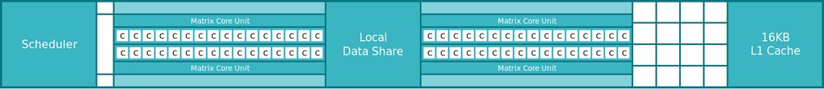

Close-up of an AMD Instinct MI250X compute unit.

The interesting thing to note with these compute units is that both 64-bit and 32-bit floating instructions are executed natively **at the same rate**. Therefore only the increased bandwidth requirements for moving 64-bit numbers around is a consideration for performance. Below is a table of performance numbers for each of the four MI250X processors in a node.

#### GPU specifications

[output not shown]

## Job queues

On Setonix the following queues are available for general use:

[output not shown]

## Interactive jobs on GPU nodes

When compiling software or running test jobs with GPU's it is helpful to have access to a "live" node. Allocations for the **gpu** queue on Setonix need a separate account. At present this will be the account name followed by **-gpu**. The following command will set up an interactive job on the **gpu** queue of Setonix. You can use this to compile software and run interactive jobs on a gpu node of Setonix.

```
salloc --account ${PAWSEY_PROJECT}-gpu --ntasks 1 --mem 4GB --cpus-per-task 1 --time 1:00:00 --gpus-per-task 1 --partition gpu
```

## Building software for Setonix

The main complexity with building HIP enabled applications on Setonix is if you also need MPI support. Otherwise you can load the **rocm** module and simply use **hipcc**. Here are some extra modules to load if you also need MPI support.

### Software modules

There are three main programming environments available on Setonix. Each provides C/C++ and Fortran compilers that build software with knowledge of of the MPI libraries available on Setonix. The **PrgEnv-GNU** programming environment uses the GNU compilers, **PrgEnv-aocc** uses the AMD **aocc** optimising compiler to try and get the best performance from the AMD CPU's on Setonix, and the **PrgEnv-cray** compilers use the compilers from Cray. Use these commands to find which module to load.

| Programming environment | command to use |
| --- | --- |
| AMD | `module avail PrgEnv-aocc` |
| Cray | `module avail PrgEnv-cray` |
| GNU | `module avail PrgEnv-gnu` |

When compiling HIP sources you have the choice of either the the ROCM **hipcc** compiler wrapper or the Cray compiler wrapper **CC** from **PrgEnv-cray**. If you use the Cray compiler wrapper you need to swap to the module **PrgEnv-cray** as the GNU programming environment (**PrgEnv-gnu**) is loaded by default.

```
module swap PrgEnv-gnu PrgEnv-cray
```

Then the following compiler wrappers are available for use to compile source files:

| Command | Explanation |
| --- | --- |
| cc | C compiler |
| CC | C++ compiler |
| ftn | FORTRAN compiler |

In order to use the GPU-aware MPI library you also need to load the **craype-accel-amd-gfx90a** module, which works in all three programming environments. To see which version to load run this command.

```
module avail craype-accel-amd-gfx90a
```

Load the module **craype-accel-amd-gfx90a** then set the environment variable

```
export MPICH_GPU_SUPPORT_ENABLED=1
```

Finally, in order to have ROCM software (such as hipcc and rocgdb) and libraries available you need to have the **rocm** module loaded. To see which one to load, run this command:

```
module avail rocm
```

The **rocm** module is independent of the programming environment module loaded.

### Compiling software with HIP and MPI support

According to this [documentation](https://docs.amd.com/bundle/HIP-Programming-Guide-v5.0/page/Transitioning_from_CUDA_to_HIP.html) the AMD compiler wrapper **hipcc** can be use for compiling HIP source files and is the suggested linker for program objects.

#### Compiling and linking with the **hipcc** compiler wrapper

You can use these compiler flags to bring in the MPI headers and make sure **hipcc** compiles kernels for the MI250X GPU's on Setonix.

| Function | flags |
| --- | --- |
| Compile | `-I${MPICH_DIR}/include --offload-arch=gfx90a` |
| Link | `-L${MPICH_DIR}/lib -lmpi ${PE_MPICH_GTL_DIR_amd_gfx90a} ${PE_MPICH_GTL_LIBS_amd_gfx90a}` |
| Debug (compile and link) | `-ggdb` |
| OpenMP (compile and link) | `-fopenmp` |

If you want **hipcc** to behave like Cray **CC**, make sure the **PrgEnv-cray** and **craype-accel-amd-gfx90a** modules are also loaded. Then you can add the output of this command,

```
$(CC --cray-print-opts=cflags)
```

to the hipcc compile flags, and the output of this command,

```
$(CC --cray-print-opts=libs)
```

to the hipcc linker flags.

#### Compiling and linking with the Cray **CC** compiler wrapper

If you are using the Cray compiler wrapper **CC** you can add these flags to compile and link HIP code for the MI250X GPU's on Setonix. You need to have the **rocm** module loaded.

| Function | flags |
| --- | --- |
| Compile | `-D__HIP_ROCclr__ -D__HIP_ARCH_GFX90A__=1 --offload-arch=gfx90a -x hip` |
| Link |  |
| Debug (compile and link) | `-g` |
| OpenMP (compile and link) | `-fopenmp` |

#### Mixing hipcc and Cray compilation

From this [documentation](https://docs.amd.com/bundle/HIP-Programming-Guide-v5.0/page/Transitioning_from_CUDA_to_HIP.html) it is important to note that all code links back to the same C++ standard libraries. The command `hipconfig --cxx` generates extra compile flags that might be useful for including in the build process with the Cray wrapper.

## Exercise: compile and run your first MPI-enabled HIP application

In the files hello_devices_mpi.cpp and hello_devices_mpi_onefile.cpp are files to implement an MPI-enabled HIP application that reports on devices and fills a vector. The difference between the two is that for hello_devices_mpi.cpp has the kernel located in a separate file kernels.hip.cpp. Your task is to compile these files into two executables, **hello_devices_mpi.exe** and **hello_devices_mpi_onefile.exe**.

### Compilation steps

#### Compile the kernel and main program in separate files

1. Compile the kernel file kernels.hip.cpp  
   `hipcc -c kernels.hip.cpp --offload-arch=gfx90a -o kernels.o`
2. Use **CC** to compile the file hello_devices_mpi.cpp. Make sure to include the location of the **hip_helper.hpp** library, located in ../include.  
   `CC -c -D__HIP_ROCclr__ -D__HIP_ARCH_GFX90A__=1 --offload-arch=gfx90a -I../include -x hip hello_devices_mpi.cpp -o hello_devices_mpi.o`
3. Use **hipcc** to link the object files together in a way that is aware of the MPI library.  
   `hipcc kernels.o hello_devices_mpi.o -o hello_devices_mpi.exe -L${MPICH_DIR}/lib -lmpi ${PE_MPICH_GTL_DIR_amd_gfx90a} ${PE_MPICH_GTL_LIBS_amd_gfx90a}`

#### Compile the combined file in one go using **hipcc**

`hipcc -I${MPICH_DIR}/include -I../include --offload-arch=gfx90a hello_devices_mpi_onefile.cpp -o hello_devices_mpi_onefile_hipcc.exe -L${MPICH_DIR}/lib -lmpi ${PE_MPICH_GTL_DIR_amd_gfx90a} ${PE_MPICH_GTL_LIBS_amd_gfx90a}`

#### Compile the combined file in one go using **CC**

`CC -D__HIP_ROCclr__ -D__HIP_ARCH_GFX90A__=1 --offload-arch=gfx90a -I../include -x hip hello_devices_mpi_onefile.cpp -o hello_devices_mpi_onefile_CC.exe`

### Run the compiled code

Using **srun** we can run the executable files. If we don't use **srun** then it will pick up all the GPU's on a node.

1. `srun ./hello_devices_mpi.exe`
2. `srun ./hello_devices_mpi_onefile_hipcc.exe`
3. `srun ./hello_devices_mpi_onefile_CC.exe`

### Bonus task: Try running these programs with and without **srun** to see what happens.

### The answer

If you get stuck, the example Makefile contains the above compilation steps. Assuming you loaded the right modules defined above, the make command is run as follows:

`make clean; make`

The script **run_compile.sh** contains the necessary commands to load the appropriate modules and run the **make** command.

```
chmod 700 run_compile.sh
   ./run_compile.sh
```

## Tips for batch jobs with HIP on GPU nodes

Pawsey has extensive documentation available for running jobs, at this [site](https://support.pawsey.org.au/documentation/display/US/Running+Jobs+in+Setonix). Here is some information that is specific to making best use of the GPU nodes on Setonix.

### GPU node configuration

On the GPU nodes of Setonix there is 1 CPU and 8 compute devices. Each of the 8 chiplets in the CPU is intended to have optimal access to one of the 8 available GPU compute devices. Shown below is a hardware diagram of a compute node, where each chiplet has optimal access to one compute device.

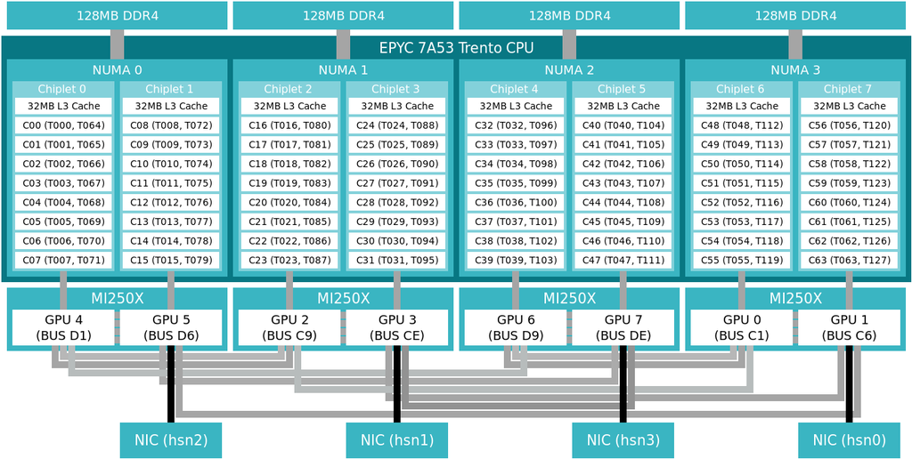

Overall view of a Setonix GPU node, showing the placement of hardware threads and the closest available compute device.

Work is still being done on making sure that MPI processes map optimally to available compute devices. These suggestions will help space out the MPI tasks so each task resides on its own chiplet.

- Use **--ntasks-per-node=8** to allocate up to 8 MPI tasks per node, one per compute device.
- Use **--gpus-per-task=1** to allocate 1 compute device per MPI task.
- Use **--cpus-per-task=8** and **--threads-per-core=1** to allocate all available threads in a chiplet to a single MPI process.
- Use the **--gpu-bind=closest** option to bind each compute device to the closest MPI task.

### Example job script

The suggested job script below will allocate an MPI task for every compute device on a node of Setonix. Then it will allocate 8 OpenMP threads to each MPI task. We can use the helper program hello_jobstep.cpp adapted from a [program](https://code.ornl.gov/olcf/hello_jobstep) by Thomas Papatheodore from ORNL. Every software thread executed by the program reports the MPI rank, OpenMP thread, the CPU hardware thread, as well as the GPU and BUS ID's of the GPU hardware.

```
#!/bin/bash -l

#SBATCH --account=<account>-gpu    # your account
#SBATCH --partition=gpu            # Using the gpu partition
#SBATCH --ntasks=8                 # Total number of tasks
#SBATCH --ntasks-per-node=8        # Set this for 1 mpi task per compute device
#SBATCH --cpus-per-task=8          # How many OpenMP threads per MPI task
#SBATCH --threads-per-core=1       # How many OpenMP threads per core
#SBATCH --gpus-per-task=1          # How many HIP compute devices to allocate to a  task
#SBATCH --gpu-bind=closest         # Bind each MPI taks to the nearest GPU
#SBATCH --mem=4000M                #Indicate the amount of memory per node when asking for share resources
#SBATCH --time=01:00:00

module swap PrgEnv-gnu PrgEnv-cray
module load craype-accel-amd-gfx90a
module load rocm

export OMP_NUM_THREADS=$SLURM_CPUS_PER_TASK   #To define the number of OpenMP threads available per MPI task, in this case it will be 8
export OMP_PLACES=cores     #To bind to cores
export OMP_PROC_BIND=close  #To bind (fix) threads (allocating them as close as possible). This option works together with the "places" indicated above, then: allocates threads in closest cores.

# Temporal workaround for avoiding Slingshot issues on shared nodes:
export FI_CXI_DEFAULT_VNI=$(od -vAn -N4 -tu < /dev/urandom)

# Run a job with task placement and $BIND_OPTIONS
#srun -N $SLURM_JOB_NUM_NODES -n $SLURM_NTASKS -c $OMP_NUM_THREADS $BIND_OPTIONS  ./hello_jobstep.exe
srun -N $SLURM_JOB_NUM_NODES -n $SLURM_NTASKS -c $OMP_NUM_THREADS ./hello_jobstep.exe | sort
```

In the file jobscript.sh is a batch script for the information above. Edit the \<account> infomation to include the account to charge to and then run the script with

```
sbatch jobscript.sh
```

Have a look at the .out file and examine how the threads and GPU's are placed.